# Análise da Paisagem

Aula 04 - Ecologia da Paisagem: Matriz, Mancha e Corredor  
Curso de Geografia

Luiz Diego Vidal Santos

## Visão Geral da Aula

### Tópicos

- 1 Discussão da leitura (Metzger, 2001)
- 2 Ecologia da paisagem: duas abordagens
- 3 O modelo matriz-mancha-corredor
- 4 Tipos e atributos de manchas
- 5 Corredores: tipos e funções
- 6 Conectividade e implicações para diagnóstico
- 7 Atividade prática: identificação em mosaico

**Objetivo da Aula**

Compreender os fundamentos da **Ecologia da Paisagem**, particularmente o modelo **matriz-mancha-corredor**, e suas implicações para o diagnóstico territorial e o planejamento da conservação.

# 1 - DISCUSSÃO DA LEITURA

## Metzger (2001): pontos-chave

### O que Metzger propõe?

> A ecologia da paisagem é *“o estudo da estrutura, função e dinâmica de áreas heterogêneas compostas por ecossistemas interativos”* - adaptado de Forman & Godron (1986)

**Duas abordagens:**

| Abordagem | Ênfase | Origem |
| --- | --- | --- |
| **Geográfica** | Relação sociedade-natureza; planejamento | Europa (Troll, Naveh) |
| **Ecológica** | Padrão espacial e processos ecológicos | América do Norte (Forman, Turner) |

Metzger argumenta que **ambas** são necessárias e complementares.

**Questões para discussão**

1. Metzger distingue **abordagem geográfica** e **ecológica**. Qual delas se aproxima mais do nosso objetivo na disciplina?
2. O autor define paisagem como “mosaico heterogêneo”. Essa definição é **suficiente** para trabalho?
3. Quais são as **três dimensões** de análise que Metzger destaca? (estrutura, função, dinâmica)
4. Como a ecologia da paisagem se diferencia da ecologia de ecossistemas e da biogeografia?
5. O que significa dizer que a paisagem é o “nível de organização mais adequado para estudar processos ecológicos que dependem do arranjo espacial”?

# 2 - ECOLOGIA DA PAISAGEM: DUAS ABORDAGENS

## Abordagem geográfica vs. ecológica

### Abordagem geográfica

- **Origem:** Europa (Carl Troll, Zev Naveh, Jean-Paul Amat)
- **Foco:** relação sociedade-natureza, planejamento territorial
- **Escala:** regional a local
- **Conceito de paisagem:** totalidade que inclui dimensão humana, cultural e perceptiva
- **Métodos:** cartografia de síntese, trabalho de campo, análise espacial, integração de componentes
- **Aplicação:** zoneamento, gestão ambiental, conservação

### Herança

Troll, Bertrand, Ab’Sáber, Monteiro → **geossistema** → análise integrada

**Abordagem ecológica**

- **Origem:** América do Norte (Forman, Turner, McGarigal)
- **Foco:** efeitos do padrão espacial sobre processos ecológicos
- **Escala:** paisagem (km² a centenas de km²)
- **Conceito de paisagem:** mosaico espacial heterogêneo com padrões mensuráveis
- **Métodos:** métricas de paisagem, SIG, modelagem espacial, sensoriamento remoto
- **Aplicação:** conservação, fragmentação, conectividade, biogeografia

### Herança

Forman & Godron, MacArthur & Wilson → **biogeografia de ilhas** → ecologia da paisagem quantitativa

**Nesta disciplina**, a abordagem é **integradora**: usamos o referencial geossistêmico (geográfico) para a leitura integrada, e o ferramental da ecologia da paisagem (ecológico) para a análise quantitativa de padrões e processos.

# 3 - O MODELO MATRIZ-MANCHA-CORREDOR

## A paisagem como mosaico

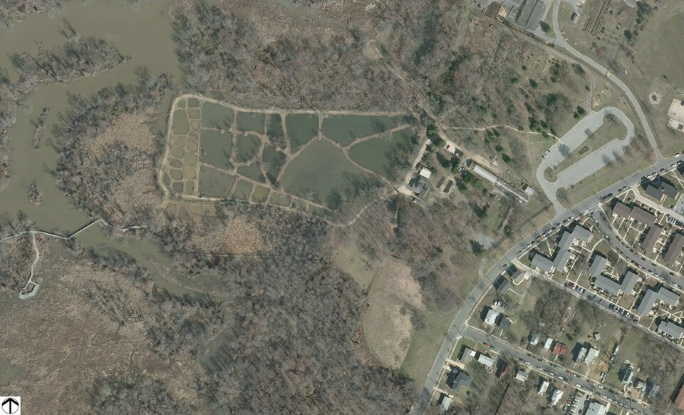

Modelo matriz-mancha-corredor em paisagem real — vista aérea

### O modelo de Forman & Godron (1986)

Toda paisagem pode ser decomposta em **três elementos estruturais**:

1. **Matriz** - o tipo de cobertura **dominante** que controla a dinâmica da paisagem
2. **Manchas** (*patches*) - unidades **discretas** que diferem da matriz
3. **Corredores** (*corridors*) - faixas **lineares** que diferem da matriz e conectam manchas

### Princípio fundamental

> O **arranjo espacial** desses três elementos determina os fluxos de energia, matéria e organismos na paisagem.

A mesma quantidade de habitat, arranjada de formas diferentes, produz paisagens com funcionalidades radicalmente distintas.

**Representação esquemática**

```
┌─────────────────────────────────┐
│  MATRIZ (pastagem)              │
│                                 │
│   ┌────┐        ┌──────┐       │
│   │ M1 │========│  M2  │       │
│   │    │corredor│      │       │
│   └────┘        └──────┘       │
│                                 │
│          ┌───┐                  │
│          │M3 │                  │
│          └───┘                  │
│                                 │
│   ┌──────────┐                  │
│   │   M4     │                  │
│   │          │                  │
│   └──────────┘                  │
└─────────────────────────────────┘
```

M1-M4 = manchas de habitat (ex.: fragmentos florestais)

O modelo é **simples**, **visual** e **operacional**.

## A matriz

### O que define a matriz?

A **matriz** é o elemento que:

- Ocupa a **maior extensão** na paisagem
- Exerce o **maior controle** sobre a dinâmica
- Determina o **grau de permeabilidade** ao movimento de organismos
- Define o **contexto** em que manchas e corredores existem

### Critérios de identificação

1. **Área relativa** - cobre mais de 50% da paisagem?
2. **Continuidade** - é o elemento mais conectado?
3. **Controle** - domina os fluxos de matéria e energia?

**Exemplos de matriz**

| Paisagem | Matriz provável |
| --- | --- |
| Cerrado fragmentado | Pastagem / soja |
| Amazônia conservada | Floresta ombrófila |
| Zona periurbana de FSA | Pastagem / área urbana |
| Caatinga preservada | Vegetação de caatinga |
| Área irrigada do São Francisco | Agricultura irrigada |

### Matriz e qualidade

A **qualidade da matriz** (permeabilidade, hostilidade, recurso) influencia diretamente:

- Sobrevivência de organismos fora das manchas
- Probabilidade de dispersão entre manchas
- Serviços ecossistêmicos da paisagem como um todo

## Manchas: tipos e origens

### Tipos de manchas (Forman, 1995)

| Tipo | Origem | Exemplo |
| --- | --- | --- |
| **Remanescente** | Sobra da cobertura original | Fragmento florestal em área de pastagem |
| **De perturbação** | Causada por distúrbio | Área queimada, clareira de tempestade |
| **De recurso** | Determinada por condições locais | Mata ciliar, vegetação sobre rocha |
| **Introduzida** | Criada pelo ser humano | Plantação, parque urbano, reflorestamento |
| **Efêmera** | Temporária, transitória | Alagamento sazonal, floração temporária |

**Atributos das manchas**

Para analisar uma mancha, avaliamos:

- **Área** ($a$) - manchas maiores sustentam mais espécies
- **Perímetro** ($p$) - define a extensão da borda
- **Relação área/perímetro** - manchas compactas (circulares) têm relação mais favorável
- **Formato** (*shape*) - regular vs. irregular; índice de forma
- **Distância ao vizinho** - isolamento; distância euclidiana ou de custo
- **Qualidade do habitat** - estado de conservação interno

> **Biogeografia de ilhas** (MacArthur & Wilson, 1967): manchas maiores e menos isoladas sustentam mais espécies - princípio fundador da ecologia da paisagem.

## Efeito de borda

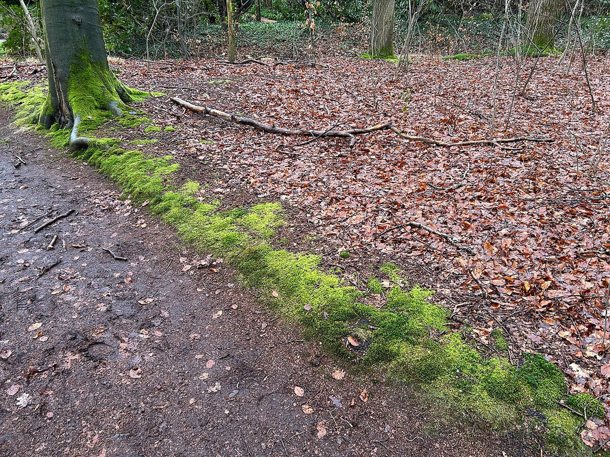

Efeito de borda em fragmento florestal

### O que é efeito de borda?

A **borda** de uma mancha é a zona de transição entre ela e a matriz. Nessa zona:

- Condições ambientais são **alteradas** (mais luz, vento, temperatura, umidade diferente)
- Espécies generalistas e invasoras **penetram**
- Espécies de interior **recuam**
- Processos de degradação **se propagam** (fogo, erosão, poluição)

### Consequências

- Manchas **pequenas** e **alongadas** têm mais borda relativa
- Manchas **grandes** e **compactas** preservam mais área de interior
- O efeito de borda pode penetrar de **30 m a > 300 m** dependendo do ecossistema e do efeito avaliado

**Exemplo numérico**

Considere dois fragmentos florestais com a mesma área (100 ha):

| Atributo | Fragmento circular | Fragmento alongado |
| --- | --- | --- |
| Área | 100 ha | 100 ha |
| Perímetro | ~3,5 km | ~6,0 km |
| Borda (100 m penetração) | ~30 ha afetados | ~55 ha afetados |
| **Área-núcleo** | **~70 ha** | **~45 ha** |

O fragmento alongado perde **mais da metade** de sua área funcional por efeito de borda!

> **Implicação para planejamento:** ao criar ou proteger fragmentos, prefira formas **compactas** com menor relação perímetro/área.

# 4 - CORREDORES

## Corredores: tipos e funções

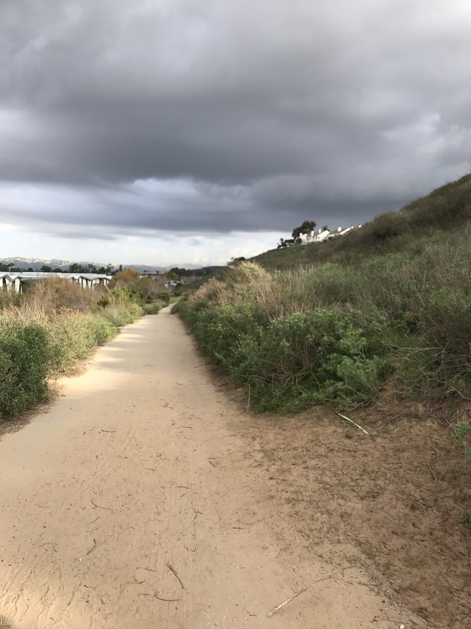

### O que é um corredor?

Faixa **linear** de cobertura que difere da matriz e pode conectar manchas. Tipos:

| Tipo | Exemplo |
| --- | --- |
| **Ripário** (fluvial) | Mata ciliar ao longo de rios |
| **De linha** | Cercas vivas, renques de árvores |
| **De faixa** | Faixa larga de vegetação entre fragmentos |
| **De estrada** | Vegetação ao longo de rodovias |
| **Funcional** | Sem estrutura física contínua, mas com uso comprovado por espécies |

### Largura importa

- Corredores **estreitos** (< 50 m) → conduzem, mas não sustentam fauna de interior
- Corredores **largos** (> 200 m) → funcionam como habitat e via de deslocamento

**Funções dos corredores**

1. **Conduto** - facilita o movimento entre manchas (dispersão, migração)
2. **Habitat** - sustenta populações residentes (se largo o suficiente)
3. **Filtro** - permite passagem seletiva (alguns organismos sim, outros não)
4. **Barreira** - pode impedir movimento (estrada como barreira para anfíbios)
5. **Sumidouro** - pode atrair organismos que não completam o ciclo de vida (armadilha ecológica)

### A legislação brasileira

O **Código Florestal** (Lei 12.651/2012) define APPs ao longo de cursos d’água - funcionam como **corredores ripários obrigatórios**.

> Matar mata ciliar é destruir o principal corredor ecológico da paisagem brasileira.

# 5 - CONECTIVIDADE

## Conectividade da paisagem

### Definição

> **Conectividade** é o grau em que a paisagem facilita ou impede o movimento de organismos entre manchas de habitat. - Taylor et al. (1993)

### Dois tipos

| Tipo | O que mede | Dados |
| --- | --- | --- |
| **Estrutural** | Arranjo físico (distância, adjacência) | Mapa de cobertura |
| **Funcional** | Capacidade real de movimento | Mapa + dados da espécie |

A conectividade **estrutural** é necessária, mas não suficiente - dois fragmentos podem estar próximos, mas separados por uma rodovia intransponível para anfíbios.

**Fatores que influenciam a conectividade**

1. **Distância entre manchas** - mais perto = mais conectado
2. **Qualidade da matriz** - permeável ou hostil?
3. **Presença de corredores** - facilitam dispersão
4. **Presença de barreiras** - rodovias, rios largos, áreas urbanas
5. **Capacidade de dispersão da espécie** - aves voam mais que anfíbios
6. **Stepping stones** - manchas pequenas que servem como “trampolins”

### Implicação para diagnóstico

Uma paisagem **fragmentada** com alta conectividade pode manter populações viáveis. Uma paisagem **com muitos fragmentos** mas baixa conectividade leva à extinção local.

> **Conectividade** pode ser mais importante que **área total** de habitat em muitos cenários.

## Fragmentação: o problema central

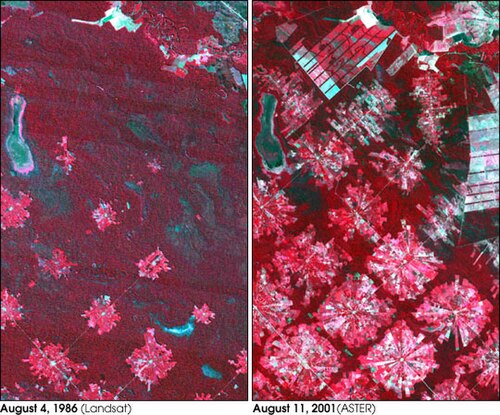

Fragmentação florestal — vista aérea de desmatamento progressivo

### O que é fragmentação?

Processo pelo qual uma área contínua de habitat é dividida em manchas menores, isoladas por uma matriz de uso diferente.

### Consequências ecológicas

1. **Perda de habitat** - redução da área total
2. **Aumento de borda** - degradação proporcional
3. **Isolamento** - redução de fluxo gênico
4. **Efeito de área** - manchas menores sustentam menos espécies
5. **Perda de espécies de interior** - sensíveis a borda
6. **Invasão por espécies generalistas** - homogeneização

**Fragmentação no Brasil**

| Bioma | Remanescente (%) | Fragmentação |
| --- | --- | --- |
| Mata Atlântica | ~12,4% | Muito alta |
| Cerrado | ~50% | Alta e crescente |
| Caatinga | ~50% | Alta (pouco monitorada) |
| Amazônia | ~80% | Em expansão (arco do desmatamento) |
| Pampa | ~36% | Alta (conversão agrícola) |
| Pantanal | ~83% | Moderada (mas fogo crescente) |

> A **Mata Atlântica** é o caso mais extremo: poucos fragmentos grandes, milhares de fragmentos pequenos e isolados. A Caatinga caminha para cenário semelhante.

# 6 - IMPLICAÇÕES PARA DIAGNÓSTICO

## Da ecologia da paisagem ao planejamento

### Princípios para o diagnóstico territorial

A ecologia da paisagem fornece princípios operacionais:

1. **Manchas grandes** são insubstituíveis - preservar
2. **Conectividade** é essencial - manter ou restaurar corredores
3. **Stepping stones** compensam parcialmente a falta de corredores contínuos
4. **Qualidade da matriz** pode ser melhorada - agrofloresta, cercas vivas
5. **Efeito de borda** deve ser minimizado - formas compactas, zonas-tampão
6. **Heterogeneidade** paisagística sustenta maior biodiversidade que homogeneidade

**Aplicação no dossiê**

Ao elaborar o dossiê da paisagem, vocês deverão:

- **Identificar** a matriz, as manchas e os corredores da área de estudo
- **Avaliar** tamanho, forma e isolamento das manchas
- **Diagnosticar** conectividade (estrutural, ao menos)
- **Identificar** barreiras e gargalos
- **Propor** diretrizes baseadas nos princípios da ecologia da paisagem

Essas análises serão aprofundadas nas aulas de **métricas** (Aulas 17-18) e **planejamento** (Aulas 21-22).

# 7 - ATIVIDADE PRÁTICA

## Exercício: identificação no mosaico

### Proposta (em duplas, 25 min)

Será projetada uma imagem de satélite (Google Earth ou MapBiomas) de uma **paisagem fragmentada** do entorno de Feira de Santana.

**Tarefa:**

1. **Identifique a matriz** - qual cobertura domina?
2. **Delimite pelo menos 5 manchas** - qual a origem provável de cada uma? (remanescente, de perturbação, introduzida, de recurso)
3. **Identifique pelo menos 2 corredores** (ou a ausência deles)
4. **Avalie qualitativamente:**
   - As manchas são grandes ou pequenas?
   - São compactas ou alongadas?
   - Estão próximas ou isoladas?
   - A paisagem tem alta ou baixa conectividade aparente?
5. **Proponha** uma intervenção para aumentar a conectividade

### Socialização (15 min)

**Critérios de avaliação do exercício**

| Critério | Peso |
| --- | --- |
| Identificação correta da matriz | 20% |
| Classificação das manchas | 20% |
| Identificação de corredores | 20% |
| Avaliação qualitativa | 20% |
| Proposta de intervenção | 20% |

> Este é um exercício de **diagnóstico visual** - será refinado com dados quantitativos nas aulas futuras.

## Para a próxima aula

### Leitura recomendada

- TURNER, M. G.; GARDNER, R. H. (2015). **Landscape Ecology in Theory and Practice**, Cap. 2 (*Causes of landscape pattern*).

### Atividade preparatória

Observar (mentalmente ou com registros) a paisagem no trajeto casa-universidade:

- Que **escalas** de padrão você percebe?
- O que muda quando você “dá zoom” (de longe para perto)?

**Na próxima aula (Aula 05)**

Entraremos em **Escalas espaço-temporais**:

- Escala geográfica vs. escala ecológica
- Hierarquias e níveis de organização
- Padrão e processo: o que vemos depende da escala
- Multiescalaridade na análise da paisagem

E na **Aula 06**:

- Fluxos, permeabilidade e conectividade em detalhe
- Fragmentação, bordas e resiliência
- Vulnerabilidade socioambiental

## Síntese da Aula 04

**O que vimos hoje**

1. **Metzger (2001)** - ecologia da paisagem geográfica vs. ecológica; ambas complementares
2. **Modelo matriz-mancha-corredor** (Forman & Godron) - base operacional para leitura do mosaico
3. **Matriz** - elemento dominante; sua qualidade determina permeabilidade
4. **Manchas** - tipos (remanescente, perturbação, recurso, introduzida); atributos (área, forma, isolamento)
5. **Efeito de borda** - degradação proporcional ao perímetro; manchas compactas preservam mais área-núcleo
6. **Corredores** - tipos e funções (conduto, habitat, filtro, barreira); importância legal (APPs)
7. **Conectividade** - estrutural vs. funcional; stepping stones; barreiras
8. **Fragmentação** - processo central; consequências ecológicas; situação dos biomas brasileiros
9. **Princípios para diagnóstico** - manchas grandes, conectividade, heterogeneidade

Obrigado!

Luiz Diego Vidal Santos

Universidade Estadual de Feira de Santana (UEFS)

Análise da Paisagem - Aula 04